# The Anatomy of a Blockbuster Movie

### Group Members: Ravi Panguluri, Joseph Yi, Vincent La

1. Introduction
2. Data Preparation
3. Exploratory Data Analysis
4. Graph Analysis
5. Regression Modeling
6. Conclusion

## Introduction

Finding blockbuster hit movies is a crucial part of any movie exective's job. Hollywood runs on big movies and finding the combination of acting, plot, and characters that piques the interest of movie-goers is vital. Continual poor box-office performance can lead to exectives of producing studios to get [axed](https://www.wsj.com/articles/SB893224454310844500). Therefore, we want to conduct a study on what traits top-selling movies tend to have. In categorizing top-blockbuster hits, we hope that these features can be used in a predictive model to show what traits movie exectives might want to have in their movies in the future, to spark big box-office turnouts.

We plan for our study to outline the entire data science lifecycle. We will begin this analysis by gathering data on movies. To do this, we will download data from the IMDB database that contains every movie ever logged onto the database with information genre, description, title, actors, characters, crew members, and average ranking. This will give us sufficient data to analyze the traits of movies that recieve high engagement with viewers. The one primary weakness of this dataset is that we do not have box office data merged to it. However, we aim to use a smaller dataset from the kaggle TMDB movie revenue box office prediction challenge. After examining the featurs of movies in the larger dataset, we can make a more informed model for the smaller dataset in order to make predictions. We will dive into more specific analyses or actors, directors, and produces to see if there are more granular trends that might give rise to that receive a lot of user engagement.

Later, to tease out specific relationships among actors, directors, and movies to analyze the "social network" phenomenon in the hollywood movie industry, we will be prototyping and visualizing multiple different graph networks through python's networkx package to see how specific relationships among actors and directors correspond to user engagement on IMDB and how they relate to movie revenues.

## Data Preparation

```python
#relevant libraries to import for our analysis
import sqlite3
import pandas as pd
import numpy as np
import matplotlib.pyplot as plt


import statsmodels.formula.api as sm
from statsmodels.tools.eval_measures import mse

from scipy.stats import zscore

from sklearn.linear_model import LinearRegression, Lasso, LassoCV, RidgeCV
from sklearn.metrics import mean_squared_error
from sklearn.ensemble import RandomForestRegressor
from sklearn import model_selection

import networkx as nx
from pyvis.network import Network

from tabulate import tabulate
```

### [Datasets](https://datasets.imdbws.com/)

The large IMDB datasets that we pulled data from are linked in the title of this section. The specific documentation is listed on the page, but here we will give a short summary of the main characteristics of each of the datasets to help explain their relevance to our analysis.

- name.basics.tsv.gz => This table lists actors, directors, and crew members by their name constants or codes that show up in other tables and then maps to their actual names. This will act as a lookup table to get specific names of agents in the hollywood industry.
- title.crew.tsv.gz => This dataset lists the codified title of the movie along with the crew members (writers and directors) that participated in the given movie
- title.principals.tsv.gz => This table gives information on the primary actors, directors, and crew members of every movie in the dataset along with relative ordering among the people's individual roles
- title.basics.tsv.gz => This gives relevant information about every movie including release year, runtime, title, age distinction, and the year of release for every movie in the dataset
- title.ratings.tsv.gz => This table gives the average rating and number of reviews for every movie in the dataset

\ Since this dataset includes millions of different movie titles, the easiest way to work the data at this volume is to export it to a SQL database, and access the data as needed through queries. Because we want to be able to demonstrate this process within our tutorial, we will read in the data once, do a bit of cleaning and export it to a db using python's sqlite3. This package allows programmers to create, read, and write to serverless databases all within the programming language of their choice.

```python
#actor_data should be names table
#ratings should be

#reading in relevant datasets
basic_data = pd.read_csv('./IMDB Data/basic_data.tsv', sep = '\t')
crew_data = pd.read_csv('./IMDB Data/crew.tsv', sep = '\t')
actor_data = pd.read_csv('./IMDB Data/main_actors_by_movie.tsv', sep= '\t')
ratings = pd.read_csv('./IMDB Data/ratings.tsv', sep = '\t')
name_table = pd.read_csv('./IMDB Data/names.tsv', sep = '\t')
```

```python
basic_data.head()
```

|  | tconst | titleType | primaryTitle | originalTitle | isAdult | startYear | endYear | runtimeMinutes | genres |
| --- | --- | --- | --- | --- | --- | --- | --- | --- | --- |
| 0 | tt0000001 | short | Carmencita | Carmencita | 0 | 1894 | \N | 1 | Documentary,Short |
| 1 | tt0000002 | short | Le clown et ses chiens | Le clown et ses chiens | 0 | 1892 | \N | 5 | Animation,Short |
| 2 | tt0000003 | short | Pauvre Pierrot | Pauvre Pierrot | 0 | 1892 | \N | 4 | Animation,Comedy,Romance |
| 3 | tt0000004 | short | Un bon bock | Un bon bock | 0 | 1892 | \N | 12 | Animation,Short |
| 4 | tt0000005 | short | Blacksmith Scene | Blacksmith Scene | 0 | 1893 | \N | 1 | Comedy,Short |

```python
#filtering for only movie data, since this is the only data that will be used for the analysis
basic_data_filtered = basic_data[basic_data['titleType'] == 'movie']
```

```python
#dropping the end year column, since a movie is only released in one year
basic_data_new = basic_data_filtered.drop('endYear',axis = 1)
basic_data_new.head()
```

|  | tconst | titleType | primaryTitle | originalTitle | isAdult | startYear | runtimeMinutes | genres |
| --- | --- | --- | --- | --- | --- | --- | --- | --- |
| 8 | tt0000009 | movie | Miss Jerry | Miss Jerry | 0 | 1894 | 45 | Romance |
| 144 | tt0000147 | movie | The Corbett-Fitzsimmons Fight | The Corbett-Fitzsimmons Fight | 0 | 1897 | 100 | Documentary,News,Sport |
| 498 | tt0000502 | movie | Bohemios | Bohemios | 0 | 1905 | 100 | NaN |
| 570 | tt0000574 | movie | The Story of the Kelly Gang | The Story of the Kelly Gang | 0 | 1906 | 70 | Action,Adventure,Biography |
| 587 | tt0000591 | movie | The Prodigal Son | L'enfant prodigue | 0 | 1907 | 90 | Drama |

```python
#replace \N's with nans to make exporting SQL easier
basic_data = basic_data.replace({'\\N': np.nan})
```

```python
basic_data_new.head()
```

|  | tconst | titleType | primaryTitle | originalTitle | isAdult | startYear | runtimeMinutes | genres |
| --- | --- | --- | --- | --- | --- | --- | --- | --- |
| 8 | tt0000009 | movie | Miss Jerry | Miss Jerry | 0 | 1894 | 45 | Romance |
| 144 | tt0000147 | movie | The Corbett-Fitzsimmons Fight | The Corbett-Fitzsimmons Fight | 0 | 1897 | 100 | Documentary,News,Sport |
| 498 | tt0000502 | movie | Bohemios | Bohemios | 0 | 1905 | 100 | NaN |
| 570 | tt0000574 | movie | The Story of the Kelly Gang | The Story of the Kelly Gang | 0 | 1906 | 70 | Action,Adventure,Biography |
| 587 | tt0000591 | movie | The Prodigal Son | L'enfant prodigue | 0 | 1907 | 90 | Drama |

```python
crew_data.head()
```

|  | tconst | directors | writers |
| --- | --- | --- | --- |
| 0 | tt0000001 | nm0005690 | \N |
| 1 | tt0000002 | nm0721526 | \N |
| 2 | tt0000003 | nm0721526 | \N |
| 3 | tt0000004 | nm0721526 | \N |
| 4 | tt0000005 | nm0005690 | \N |

```python
crew_data = crew_data.replace({'\\N': np.nan})
crew_data.head()
```

[output not shown]

```python
actor_data.head()
```

|  | nconst | primaryName | birthYear | deathYear | primaryProfession | knownForTitles |
| --- | --- | --- | --- | --- | --- | --- |
| 0 | nm0000001 | Fred Astaire | 1899 | 1987 | soundtrack,actor,miscellaneous | tt0050419,tt0045537,tt0053137,tt0072308 |
| 1 | nm0000002 | Lauren Bacall | 1924 | 2014 | actress,soundtrack | tt0117057,tt0075213,tt0037382,tt0038355 |
| 2 | nm0000003 | Brigitte Bardot | 1934 | \N | actress,soundtrack,music_department | tt0057345,tt0049189,tt0054452,tt0056404 |
| 3 | nm0000004 | John Belushi | 1949 | 1982 | actor,soundtrack,writer | tt0072562,tt0077975,tt0078723,tt0080455 |
| 4 | nm0000005 | Ingmar Bergman | 1918 | 2007 | writer,director,actor | tt0050986,tt0060827,tt0069467,tt0083922 |

```python
#same procedure as above
actor_data = actor_data.replace({'\\N': np.nan})
actor_data.head()
```

[output not shown]

```python
ratings.head()
```

|  | tconst | averageRating | numVotes |
| --- | --- | --- | --- |
| 0 | tt0000001 | 5.7 | 1966 |
| 1 | tt0000002 | 5.8 | 264 |
| 2 | tt0000003 | 6.5 | 1810 |
| 3 | tt0000004 | 5.6 | 178 |
| 4 | tt0000005 | 6.2 | 2610 |

```python
ratings = ratings.replace({'\\N': np.nan})
ratings
```

[output not shown]

```python
name_table.head()
```

|  | tconst | ordering | nconst | category | job | characters |
| --- | --- | --- | --- | --- | --- | --- |
| 0 | tt0000001 | 1 | nm1588970 | self | \N | ["Self"] |
| 1 | tt0000001 | 2 | nm0005690 | director | \N | \N |
| 2 | tt0000001 | 3 | nm0374658 | cinematographer | director of photography | \N |
| 3 | tt0000002 | 1 | nm0721526 | director | \N | \N |
| 4 | tt0000002 | 2 | nm1335271 | composer | \N | \N |

```python
name_table = name_table.replace({'\\N': np.nan})
name_table.head()
```

[output not shown]

```python
#NOTE: running this line of code establishes connection to the SQL db
conn = sqlite3.connect('imdb.db')
c = conn.cursor()
```

### Writing the Data to SQL

This next cell is responsible for writing all of the tables after preprocessing and filtering into the SQL database. On the python side, we did limited data cleaning and filtering because those operations are very costly to do on the python side and will often hit upon many errors. Because SQL tables have predefined schemas, it will be faster to simply data processing like filtering and joins on that side and then doing more complicated operations on the smaller dataset in python. More a more in-depth comparison between Python and SQL for data processing tasks, check out this interesting [article](https://streamsets.com/blog/python-vs-sql/). From now on, we will be reading in smaller selections of data from the database every time we want to conduct an analysis.

```python
#This segment of code only needs to be run once!

#These lines of code, push all of the tables to SQL with names so that when they are queried, we know which table to pull from
name_table.to_sql(name='principals', con=conn, if_exists='replace', index=False)
actor_data.to_sql(name='names', con=conn, if_exists='replace', index=False)
basic_data.to_sql(name = 'media', con = conn, if_exists='replace', index = False)
ratings.to_sql(name = 'ratings', con = conn, if_exists='replace', index = False)
crew_data.to_sql(name = 'crew', con = conn, if_exists='replace', index = False)

#After pushing the data to SQL, commit all the changes to the DB
conn.commit()
```

## Exploratory Data Analysis

Now we want to do some basic data munging on the SQL side, and get into analyzing some of the key features of this dataset! Since box office data wasn't that accurate till [at least the 1970's](https://slate.com/news-and-politics/2009/07/why-journalists-don-t-account-for-inflation-when-they-report-box-office-records.html), we'll pick a year later in the 1970's to act as the lower bound for movie release dates.

```python
#Join movie titles with basic information on movies and join with data from the ratings table
box_office_movies = pd.read_sql_query('''
                                            SELECT media.tconst, titleType, primaryTitle, startYear, genres, averageRating, numVotes
                                            FROM media INNER JOIN ratings ON media.tconst = ratings.tconst
                                            WHERE titleType = 'movie'
                                            AND startYear >= 1977
                                      '''
                                , conn)
```

```python
#from printing the head of the df, looks like what we have is right
box_office_movies.head()
```

|  | tconst | titleType | primaryTitle | startYear | genres | averageRating | numVotes |
| --- | --- | --- | --- | --- | --- | --- | --- |
| 0 | tt0013274 | movie | Istoriya grazhdanskoy voyny | 2021 | Documentary | 6.8 | 56 |
| 1 | tt0015414 | movie | La tierra de los toros | 2000 | None | 5.3 | 16 |
| 2 | tt0015724 | movie | Dama de noche | 1993 | Drama,Mystery,Romance | 6.1 | 26 |
| 3 | tt0035423 | movie | Kate & Leopold | 2001 | Comedy,Fantasy,Romance | 6.4 | 86568 |
| 4 | tt0036606 | movie | Another Time, Another Place | 1983 | Drama,War | 6.5 | 338 |

## Distribution of Movies with High IMDB Engagement

The first plot that we are going to make is one that teases out how frequently movies become popular. Making this plot will be an important starting point to jump from for any further analysis because we want to have some idea of the underlying distribution of movie popularity. Because we do not have access to a larger dataset of box office metrics, we will be using IMDB ratings as a rough proxy for popularity on the larger dataset.

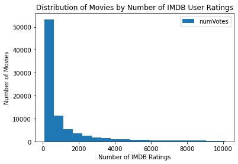

```python
#since there are way more movies in the lower end of the range, make the bins closer together
lower_bins = np.linspace(0,100, 20)
upper_bins = np.linspace(100, 10000, 20)

box_office_movies.plot(kind = 'hist', y = 'numVotes', bins = lower_bins + upper_bins)
plt.xlabel("Number of IMDB Ratings")
plt.ylabel("Number of Movies")
plt.title("Distribution of Movies by Number of IMDB User Ratings")
```

#### Power Law Distribution Interpretation

As we can see from the plot above, using the number of ratings that a movie receives on IMDB follow a [power law distribution](https://fs.blog/power-laws/). For more on the significance and just how commonly this distribution appears, look at this fascinating article that describes more on the phenomenon. However, the main idea is that in some sense people are often watching and reviewing movies based on what their friends watch, or what movies have been most heavily promoted on social media. This means that is likely some universal connection between IMDB users that's causing only a few movies to garner so much attention. In this case, the power law distribution implies that many (if not most) of the total reviews come from a small subset of the most popular movies in the IMDB. This makes sense in context with the fact that many different types of [popular media](https://michaeltauberg.medium.com/power-law-in-popular-media-7d7efef3fb7c) also tend to follow this distribution.

Now, it might be prudent to see if there are underlying factors causing this. For instance, IMDB reviewers could be drawn in by specific actors, directors, or genres that all tend to garner more attention than most others. The next step is to make different versions of this graph, but instead of focusing on movies, we want to focus more specifically on crew members.

#### Getting Data for Directors

```python
#Read in a new table, but grab more variables than before and pull data on directors and writers of movies
director_movies = pd.read_sql_query('''
                                        SELECT media.tconst, titleType, primaryTitle, startYear, genres, averageRating, numVotes, directors, writers, runtimeMinutes, isAdult
                                        FROM media
                                        INNER JOIN ratings
                                        ON media.tconst = ratings.tconst
                                        INNER JOIN crew
                                        ON media.tconst = crew.tconst
                                        WHERE titleType = 'movie' AND startYear >= 1977
                                    ''', conn)
```

```python
director_movies.head()
```

|  | tconst | titleType | primaryTitle | startYear | genres | averageRating | numVotes | directors | writers | runtimeMinutes | isAdult |
| --- | --- | --- | --- | --- | --- | --- | --- | --- | --- | --- | --- |
| 0 | tt0013274 | movie | Istoriya grazhdanskoy voyny | 2021 | Documentary | 6.8 | 56 | nm0412842,nm0895048 | None | 94 | 0 |
| 1 | tt0015414 | movie | La tierra de los toros | 2000 | None | 5.3 | 16 | nm0615736 | None | 60 | 0 |
| 2 | tt0015724 | movie | Dama de noche | 1993 | Drama,Mystery,Romance | 6.1 | 26 | nm0529960 | nm0529960,nm1597742 | 102 | 0 |
| 3 | tt0035423 | movie | Kate & Leopold | 2001 | Comedy,Fantasy,Romance | 6.4 | 86568 | nm0003506 | nm0737216,nm0003506 | 118 | 0 |
| 4 | tt0036606 | movie | Another Time, Another Place | 1983 | Drama,War | 6.5 | 338 | nm0705535 | nm0450407,nm0485392,nm0705535 | 118 | 0 |

As we can see, if there arer multiple directors for a single movie, they will appear as comma-separated values. This representation will make it difficult to plot movies by directors. Therefore, the next logical step is to explode the column, or making a new row for each comma-separated value in the column. However, in order to employ this function, we must first transform the data in the [rows to be list like](https://pandas.pydata.org/docs/reference/api/pandas.DataFrame.explode.html). To do this, will will split the column values into list items based on the comma delimiter by using the split method. After that we can directly apply the exploding operation.

```python
directors_exploded = director_movies.assign(directors=director_movies['directors'].str.split(',')).explode('directors')
```

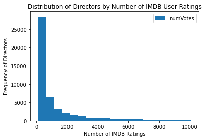

```python
#do the same procedure as before to make variable-spaced bins
lower_bins = np.linspace(0, 100, 20)
higher_bins = np.linspace(100, 10000, 20)

#group by directors to make the plots
directors_exploded.groupby('directors')['numVotes'].sum().reset_index().plot(kind = 'hist', y = 'numVotes', bins =  lower_bins + higher_bins)
plt.xlabel("Number of IMDB Ratings")
plt.ylabel("Frequency of Directors")
plt.title("Distribution of Directors by Number of IMDB User Ratings")
```

From this plot, it is also clear that the data tend to follow a power law distribution. This means that there are a small number of directors that make it big in the movie industry.

```python
#Now we're just repeating the same procedure as before, but instead with writers this time
writers_exploded = director_movies.assign(writers=director_movies['writers'].str.split(',')).explode('writers')
```

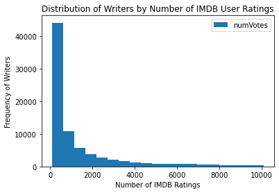

```python
lower_bins = np.linspace(0, 100, 20)
higher_bins = np.linspace(100, 10000, 20)

writers_exploded.groupby('writers')['numVotes'].sum().reset_index().plot(kind = 'hist', y = 'numVotes', bins = lower_bins + higher_bins)
plt.xlabel("Number of IMDB Ratings")
plt.ylabel("Frequency of Writers")
plt.title("Distribution of Writers by Number of IMDB User Ratings")
```

The same power law distribution is aparent for the writers and their reviews. Of course this would only make sense, given that each movie would have a set of writers and directors and the same trend would apply to all 3 categories. People watch the move popular movies and give them reviews and all of the popular movies have only a few writers and directors listed.

## [Box Office Data](https://www.kaggle.com/competitions/tmdb-box-office-prediction/data)

The next dataset that we will be using is the training dataset from the TMDB Box Office Prediction Challenge. Scraping box office data for a large number of movies in our dataset was impractical and also often against terms of service for large box office data aggregators. Therefore, to marry movie traits with some sample of box office data we used the data from a public kaggle competition. However, we only use the training dataset given in the competition. In addition, we want to see whether or not it is viable to use the IMDB metrics as a proxy for movie popularity by any metric and to do some EDA on the smaller kaggle dataset. Note that the dataset source is linked in the title of the section

```python
box_office_data = pd.read_csv('./tmdb-box-office-prediction/train.csv')
```

```python
box_office_data.head()
```

|  | id | belongs_to_collection | budget | genres | homepage | imdb_id | original_language | original_title | overview | popularity | ... | release_date | runtime | spoken_languages | status | tagline | title | Keywords | cast | crew | revenue |
| --- | --- | --- | --- | --- | --- | --- | --- | --- | --- | --- | --- | --- | --- | --- | --- | --- | --- | --- | --- | --- | --- |
| 0 | 1 | [{'id': 313576, 'name': 'Hot Tub Time Machine ... | 14000000 | [{'id': 35, 'name': 'Comedy'}] | NaN | tt2637294 | en | Hot Tub Time Machine 2 | When Lou, who has become the "father of the In... | 6.575393 | ... | 2/20/15 | 93.0 | [{'iso_639_1': 'en', 'name': 'English'}] | Released | The Laws of Space and Time are About to be Vio... | Hot Tub Time Machine 2 | [{'id': 4379, 'name': 'time travel'}, {'id': 9... | [{'cast_id': 4, 'character': 'Lou', 'credit_id... | [{'credit_id': '59ac067c92514107af02c8c8', 'de... | 12314651 |
| 1 | 2 | [{'id': 107674, 'name': 'The Princess Diaries ... | 40000000 | [{'id': 35, 'name': 'Comedy'}, {'id': 18, 'nam... | NaN | tt0368933 | en | The Princess Diaries 2: Royal Engagement | Mia Thermopolis is now a college graduate and ... | 8.248895 | ... | 8/6/04 | 113.0 | [{'iso_639_1': 'en', 'name': 'English'}] | Released | It can take a lifetime to find true love; she'... | The Princess Diaries 2: Royal Engagement | [{'id': 2505, 'name': 'coronation'}, {'id': 42... | [{'cast_id': 1, 'character': 'Mia Thermopolis'... | [{'credit_id': '52fe43fe9251416c7502563d', 'de... | 95149435 |
| 2 | 3 | NaN | 3300000 | [{'id': 18, 'name': 'Drama'}] | http://sonyclassics.com/whiplash/ | tt2582802 | en | Whiplash | Under the direction of a ruthless instructor, ... | 64.299990 | ... | 10/10/14 | 105.0 | [{'iso_639_1': 'en', 'name': 'English'}] | Released | The road to greatness can take you to the edge. | Whiplash | [{'id': 1416, 'name': 'jazz'}, {'id': 1523, 'n... | [{'cast_id': 5, 'character': 'Andrew Neimann',... | [{'credit_id': '54d5356ec3a3683ba0000039', 'de... | 13092000 |
| 3 | 4 | NaN | 1200000 | [{'id': 53, 'name': 'Thriller'}, {'id': 18, 'n... | http://kahaanithefilm.com/ | tt1821480 | hi | Kahaani | Vidya Bagchi (Vidya Balan) arrives in Kolkata ... | 3.174936 | ... | 3/9/12 | 122.0 | [{'iso_639_1': 'en', 'name': 'English'}, {'iso... | Released | NaN | Kahaani | [{'id': 10092, 'name': 'mystery'}, {'id': 1054... | [{'cast_id': 1, 'character': 'Vidya Bagchi', '... | [{'credit_id': '52fe48779251416c9108d6eb', 'de... | 16000000 |
| 4 | 5 | NaN | 0 | [{'id': 28, 'name': 'Action'}, {'id': 53, 'nam... | NaN | tt1380152 | ko | 마린보이 | Marine Boy is the story of a former national s... | 1.148070 | ... | 2/5/09 | 118.0 | [{'iso_639_1': 'ko', 'name': '한국어/조선말'}] | Released | NaN | Marine Boy | NaN | [{'cast_id': 3, 'character': 'Chun-soo', 'cred... | [{'credit_id': '52fe464b9251416c75073b43', 'de... | 3923970 |

5 rows × 23 columns

The output from the cell above shows us a basic summary of the features of the full IMDB dataset from kaggle. This dataset has more features than the larger IMDB database, that might have interesting factors to include in our models. Most specifically, the budget and original langauge factors look to be very interesting factors that could potentially have a high impact on the movie's revenues.

```python
box_office_data['imdb_id']
```

```
0       tt2637294
1       tt0368933
2       tt2582802
3       tt1821480
4       tt1380152
          ...
2995    tt0109403
2996    tt2364975
2997    tt0116908
2998    tt0343135
2999    tt1600195
Name: imdb_id, Length: 3000, dtype: object
```

From this, we can see that the IMDB id column exactly corresponds to the tconst attribute in the IMDB datasets. We can use the IMDB id to join these two datasets together.

```python
#merge IMDB and additional TMDB features toggether
box_office_and_imdb = pd.merge(left= box_office_data, right = director_movies, left_on = 'imdb_id', right_on = 'tconst', how = 'inner')
```

```python
print(f"The features of the dataset are {box_office_and_imdb.columns.values}")
```

```
The features of the dataset are ['id' 'belongs_to_collection' 'budget' 'genres_x' 'homepage' 'imdb_id'
 'original_language' 'original_title' 'overview' 'popularity'
 'poster_path' 'production_companies' 'production_countries'
 'release_date' 'runtime' 'spoken_languages' 'status' 'tagline' 'title'
 'Keywords' 'cast' 'crew' 'revenue' 'tconst' 'titleType' 'primaryTitle'
 'startYear' 'genres_y' 'averageRating' 'numVotes' 'directors' 'writers'
 'runtimeMinutes' 'isAdult']
```

Looking at the list of features, the ones that are (intuitively speaking) the most predictive of box office revenue are the production country, original language, and budget. As such, when evaluating factors for our models, these factors are likely the ones to come into play the most.

```python
box_office_and_imdb.head()
```

|  | id | belongs_to_collection | budget | genres_x | homepage | imdb_id | original_language | original_title | overview | popularity | ... | titleType | primaryTitle | startYear | genres_y | averageRating | numVotes | directors | writers | runtimeMinutes | isAdult |
| --- | --- | --- | --- | --- | --- | --- | --- | --- | --- | --- | --- | --- | --- | --- | --- | --- | --- | --- | --- | --- | --- |
| 0 | 1 | [{'id': 313576, 'name': 'Hot Tub Time Machine ... | 14000000 | [{'id': 35, 'name': 'Comedy'}] | NaN | tt2637294 | en | Hot Tub Time Machine 2 | When Lou, who has become the "father of the In... | 6.575393 | ... | movie | Hot Tub Time Machine 2 | 2015 | Comedy,Mystery,Sci-Fi | 5.0 | 40083 | nm0684336 | nm0372222,nm5236778 | 93 | 0 |
| 1 | 2 | [{'id': 107674, 'name': 'The Princess Diaries ... | 40000000 | [{'id': 35, 'name': 'Comedy'}, {'id': 18, 'nam... | NaN | tt0368933 | en | The Princess Diaries 2: Royal Engagement | Mia Thermopolis is now a college graduate and ... | 8.248895 | ... | movie | The Princess Diaries 2: Royal Engagement | 2004 | Comedy,Family,Romance | 5.8 | 84376 | nm0005190 | nm0127690,nm0920859,nm0722274 | 113 | 0 |
| 2 | 3 | NaN | 3300000 | [{'id': 18, 'name': 'Drama'}] | http://sonyclassics.com/whiplash/ | tt2582802 | en | Whiplash | Under the direction of a ruthless instructor, ... | 64.299990 | ... | movie | Whiplash | 2014 | Drama,Music | 8.5 | 897235 | nm3227090 | nm3227090 | 106 | 0 |
| 3 | 4 | NaN | 1200000 | [{'id': 53, 'name': 'Thriller'}, {'id': 18, 'n... | http://kahaanithefilm.com/ | tt1821480 | hi | Kahaani | Vidya Bagchi (Vidya Balan) arrives in Kolkata ... | 3.174936 | ... | movie | Kahaani | 2012 | Mystery,Thriller | 8.1 | 63893 | nm1223910 | nm1223910,nm4298729,nm1330994,nm1937760,nm1399... | 122 | 0 |
| 4 | 5 | NaN | 0 | [{'id': 28, 'name': 'Action'}, {'id': 53, 'nam... | NaN | tt1380152 | ko | 마린보이 | Marine Boy is the story of a former national s... | 1.148070 | ... | movie | Marine Boy | 2009 | Action,Thriller | 5.7 | 321 | nm3334279 | nm3334279 | 118 | 0 |

5 rows × 34 columns

Next let's investigate the theoretical assumption that we have been hinting at throughout this analysis: using number of IMDB votes as a proxy for revenue. Now that we have a sample of data with both box office revenue and the number of votes, we can investigate how valid this assumption is.

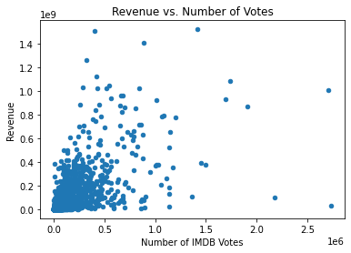

```python
#making a scatter plot of revenue and IMDB votes to visually explore the relationship
box_office_and_imdb.plot(kind = 'scatter', x = 'numVotes', y = 'revenue')
plt.title('Revenue vs. Number of Votes')
plt.xlabel("Number of IMDB Votes")
plt.ylabel("Revenue")
```

From this plot, we can see a decently strong positive association between the two. In other words, a higher number of IMDB votes seems to roughly correspond to higher revenue. But from this scatter plot, it appears that the error of any regression line between the two would be reasonably high. In addition, there appear to be clear outliers in this dataset, so using this as a proxy (especially with non-penalized regression, may be improperly fit). Let's investigate the correlation between the two to just see the strength of the relationship.

```python
box_office_and_imdb[['numVotes', 'revenue']].corr()
```

|  | numVotes | revenue |
| --- | --- | --- |
| numVotes | 1.000000 | 0.636017 |
| revenue | 0.636017 | 1.000000 |

Again the correlation is reasonably high at 0.63, but the errors and outliers as indicated by the scatter plot make us skeptical that the benefits from having more training data for the model. In addition, the richness of the kaggle dataset will likely outweigh any deficencies in the volume of movies that we can use to train and test our model on.

## Examining Potential Factors for Predictive Box Office Modelling

At this stage, we are ready to start using the traits from a wealth of movies to predict the box office revenue of movies. The first step in this process is selecting the factors. For right now, we are going to do some exploration on a few key factors that may potentially help develop a predictive model.

- Genre: Certain types of movies may generally garner more attention from viewers. For instance, it seems reasonably likely that action movies will perform better than musicals in the box office. Thus, while I don't think it will be the most important factor, I think there could be some relationship between genre and number of ratings. Note that we cannot use this factor as-is, since regressions will not work with categorical factors. Therefore, we need to employ a procedure called one-hot encoding. This process turns a categorical column into a boolean column with 0 to represent false and 1 to represent true. We will do a little but of exploration to select the genres that might be most impactful to use.
- Region: The globe does not have an even distribution of movie successes. Often one a few regions tend to [dominate in movie sales](https://www.nationmaster.com/country-info/stats/Media/Cinema-attendance-per-capita). It's also possible that since different genres are more popular in different regions, we could add an interaction term in our regression between region and genre. Some more EDA will also flesh out this relationship. We can derive this variable from the original language of release and the primary spoken language.
- Weighted Director Rating: This is a factor that we will attempt to derive from variables that we have in the IMDB dataset. The intuition behind this factor is that if directors receive high average ratings then they are more likely to produce top-hit movies in the future. Further, if they have been in a large number of movies, then that establishes even more confidence that they will produce high-selling movies. More details about this factor will be determined below when we actually construct the factor.
- Budget: It seems to make perfect sense that if a movie has a higher budget behind it, it is likely to make more revenue. High budget movies seem likely to be the ones that have the most advertising behind them (because movie studios want to make their money back on their high investments). As we touched on in the introduction, movie producers make large investments in specific cast members, directors, and writers in the hopes that they will make money on the movie. This factor will likely be highly indicative of a big box-office hit.

```python
# multiple genres are also listed for a movie as a comma-separated row value, so the same explosion procedure will be used to extract all the genres
genre_exploded = box_office_and_imdb.assign(genres=box_office_and_imdb['genres_y'].str.split(',')).explode('genres')
```

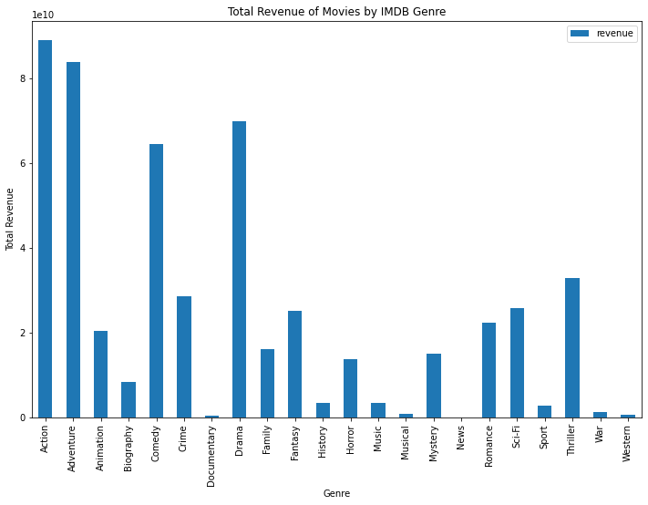

```python
fig, ax = plt.subplots(figsize= (12, 8))
#group by genre and plot the total number of votes per genre
genre_totals = genre_exploded.groupby('genres')['revenue'].sum().reset_index()
genre_totals.plot(kind = 'bar', x = 'genres', y = 'revenue', ax = ax)
ax.set_xlabel("Genre")
ax.set_ylabel("Total Revenue")
ax.set_title("Total Revenue of Movies by IMDB Genre")
```

Clearly, there are drastic differences between the number of votes that different genres get. For instance, action movies, adventure movies, and dramas seem to earn far more revenue than less popular genres like musicals. However, this graph does not control for the number of movies per genre, so the next plot that we will make will plot the revenue per movie by genre.

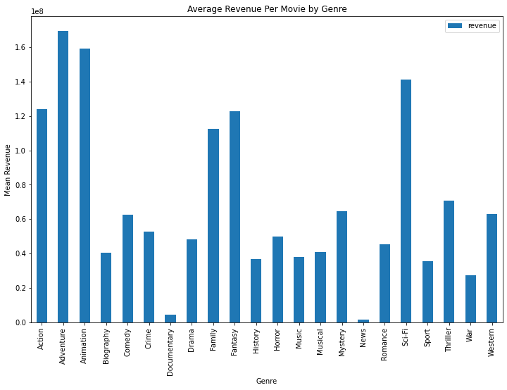

```python
fig, ax = plt.subplots(figsize= (12, 8))
genre_totals = genre_exploded.groupby('genres')['revenue'].mean().reset_index()
genre_totals.plot(kind = 'bar', x = 'genres', y = 'revenue', ax = ax)
ax.set_xlabel("Genre")
ax.set_ylabel("Mean Revenue")
ax.set_title("Average Revenue Per Movie by Genre")
```

Now looking at this plot, we can see that relative differences in popularity seem to be evident amongst genres. Some of the most popular genres are sci-fi, adventure, animation, and fantasy. These genre of a movie clearly seems to have some level of impact on the user engagement on IMDB. Therefore, this should definitely be a factor in the model that we develop.

#### Relationship Between Budget and Revenue

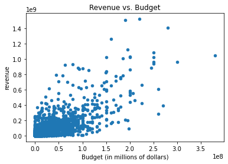

```python
box_office_and_imdb.plot(kind = 'scatter', x = 'budget', y = 'revenue')
plt.title('Revenue vs. Budget')
plt.xlabel("Budget (in millions of dollars)")
```

Here we can see a very clear positive association between budget and revenue. This relatively confirms our hypothesis from before about how movie producers excess spending on a movie likely dictates the quality of the movie production and the amount of resources and effort that they will put into marketing the movie and hiring the best personnel to do the movie. Here it seems abundantly clear that budget is an important factor to include in our model.

To use this, we need to extract the producing company names from the list of dictionaries and make that into a column.

```python
#cast column to a string
production_companies = box_office_and_imdb['production_companies'].astype(str)
#get the literal evaluation of the string at each row, or if it's an na return na
production_companies = production_companies.apply(lambda x: eval(x) if x != 'nan' else np.nan)
#drop all the na's from this series inplace
production_companies.dropna(axis = 0, inplace = True)
#apply a function to extract all of the listed production studios from the list of dictionaries
production_companies = production_companies.apply(lambda x: [d['name'] if x != np.nan else np.nan for d in x])
#assign this new series to be the new row
box_office_and_imdb['production_companies'] = production_companies
```

```python
box_office_and_imdb['production_companies']
```

```
0       [Paramount Pictures, United Artists, Metro-Gol...
1                                  [Walt Disney Pictures]
2       [Bold Films, Blumhouse Productions, Right of W...
3                                                     NaN
4                                                     NaN
                              ...
2767             [Warner Bros., Morgan Creek Productions]
2768                           [Memfis Film, Film i Väst]
2769    [New Line Cinema, Forge, The Steve Tisch Company]
2770                   [Jersey Films, Loofah Productions]
2771    [Lions Gate Films, Vertigo Entertainment, Goth...
Name: production_companies, Length: 2772, dtype: object
```

```python
production_companies_expl = box_office_and_imdb.explode('production_companies')
```

```python
production_companies_expl['production_companies']
```

```
0              Paramount Pictures
0                  United Artists
0       Metro-Goldwyn-Mayer (MGM)
1            Walt Disney Pictures
2                      Bold Films
                  ...
2771        Vertigo Entertainment
2771                 Gotham Group
2771                  Tailor Made
2771                  Mango Farms
2771      Quick Six Entertainment
Name: production_companies, Length: 7872, dtype: object
```

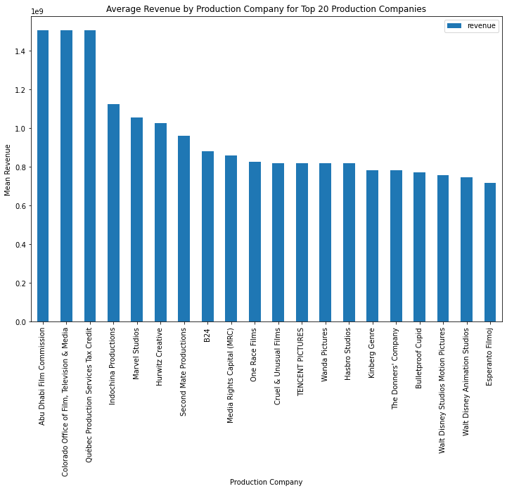

```python
fig, ax = plt.subplots(figsize= (12, 8))
prod_comp_revenues = production_companies_expl.groupby('production_companies')['revenue'].mean().reset_index()
prod_comp_revenues.nlargest(20, ['revenue']).plot(kind = 'bar', x = 'production_companies', y = 'revenue', ax = ax)
ax.set_xlabel("Production Company")
ax.set_ylabel("Mean Revenue")
ax.set_title("Average Revenue by Production Company for Top 20 Production Companies")
```

As we can see, the mean revenue per movie by production companies are wildly different, even within the top 20 production companies by revenue. This means that this is another potential factor that could be one-hot encoded and utilized in our final regression model. However, the issue with adding production companies to the regression is that it will introduce the issue where we have a sparse dataset, or a dataset with many more features than observations. The issue with this kind of dataset is that models that are trained and tested on it are more likely to overfit. For readers that are interested in the mathematical details phenomenon and potential solutions, check out this [lecture](https://www.cs.cmu.edu/~ggordon/10725-F12/scribes/10725_Lecture2.pdf). Later on, we will get into the usage of penalized regressions to solve this issue.

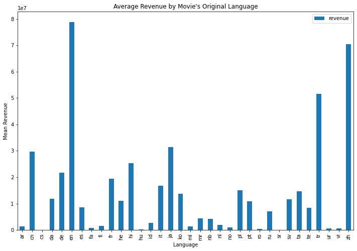

```python
fig, ax = plt.subplots(figsize= (12, 8))
movie_lang_revenues = box_office_and_imdb.groupby('original_language')['revenue'].mean().reset_index()
movie_lang_revenues.plot(kind = 'bar', x = 'original_language', y = 'revenue', ax = ax)
ax.set_xlabel("Language")
ax.set_ylabel("Mean Revenue")
ax.set_title("Average Revenue by Movie's Original Language")
```

Again we see wide ranges of mean revenues per movie by language. However, understandably the two languages that seem to stand out the most are mandarin (zh) and english language movies (en) abbreviation. This looks like another useful factor that we can use in our predictive model given the wide variance.

## Factor Development

The next step is to analyze how we can potentially use director ratings and the number of movies that they were featured in as a factor for our regression. The first step is to establish if there is any relationship between the number of ratings a director receives and how many movies they directed, to see if we can gather any insight into how to construct our unique factor.

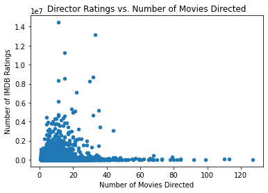

```python
directors_exploded.groupby('directors')['numVotes'].agg(['sum', 'count']).reset_index().plot(kind = 'scatter', x = 'count', y = 'sum')
plt.title('Director Ratings vs. Number of Movies Directed')
plt.xlabel("Number of Movies Directed")
plt.ylabel('Number of IMDB Ratings')
```

Based on this plot, it might be useful to make a factor for reasonable number of movies directed. At the higher end of the distribution, it appears as if many small-time directors are just chrurning out movies that do not capture the interest of IMDB users. On the other hand, it seems that directors that have made any reasonable number of movies (10 - 40) have made enough movies to be relevant, but not too many to question their committment to producing solid movies.

## Weighted Rating Calculation Attempt

metric is calulated as:

sum(average*rating{i} * numVotes*{i}) / total(numVotes)

and then normalized by z-score

```python
#calculate the raw score (total rating)
directors_exploded['score'] = directors_exploded['averageRating'] * directors_exploded['numVotes']
```

```python
#calculate the weighted scores, normalized as a z-score

#apply z_score standardization
weighted_score_df = directors_exploded.groupby('directors')['score'].sum() / directors_exploded.groupby('directors')['numVotes'].sum()
weighted_score_df = weighted_score_df.reset_index()
weighted_score_df = weighted_score_df.rename({0:'weighted_score'}, axis = 1)
weighted_score_df['weighted_score'] = (weighted_score_df['weighted_score'] - weighted_score_df['weighted_score'].mean()) / weighted_score_df['weighted_score'].std()

#just to look, print the highest 15 director weighted scores
weighted_score_df.nlargest(n=15, columns=['weighted_score'])
```

|  | directors | weighted_score |
| --- | --- | --- |
| 1346 | nm0007079 | 2.54933 |
| 2922 | nm0050286 | 2.54933 |
| 7379 | nm0183949 | 2.54933 |
| 8183 | nm0210283 | 2.54933 |
| 14191 | nm0392082 | 2.54933 |
| 16126 | nm0446018 | 2.54933 |
| 19907 | nm0551718 | 2.54933 |
| 25265 | nm0717103 | 2.54933 |
| 35472 | nm10271872 | 2.54933 |
| 36989 | nm10575776 | 2.54933 |
| 37021 | nm10583510 | 2.54933 |
| 37689 | nm10715010 | 2.54933 |
| 37859 | nm10752568 | 2.54933 |
| 38300 | nm10853616 | 2.54933 |
| 38414 | nm10878713 | 2.54933 |

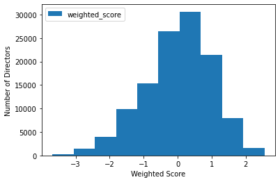

```python
#somewhat normal with skew?
weighted_score_df.plot(y='weighted_score', kind='hist')
plt.xlabel("Weighted Score")
plt.ylabel("Number of Directors")
```

Based on this histogram, the data appear to have a slighly skewed distribution, but they seem to be approximately normally distributed. Note that the standardization routine (although traditionally done on normally distributed variables) does not change the shape of the underlying distribution as it is only a linear transformation on the data points. We can test this initial hypothesis with a quantile-quantile plot that matches quantiles of this distribution up with quantiles of the normal distribution. For more on the statistical interpretation of that kind of plot [read this piece](https://data.library.virginia.edu/understanding-q-q-plots/). However, the big idea is that the closer the quantiles match up (meaning that there is a one-to-one relationship between the quantiles of the weighted score distribution and the normal distirubtion), then the more confident we can be that the distribution of weightted scores is normal.

```
((array([-4.3837717 , -4.18662813, -4.07945815, ...,  4.07945815,
          4.18662813,  4.3837717 ]),
  array([-3.68154091, -3.68154091, -3.68154091, ...,  2.54932962,
          2.54932962,  2.54932962])),
 (0.9950123828615792, 6.798276261885379e-14, 0.9949793458959189))
```

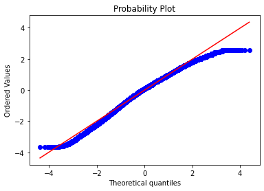

```python
# TODO: explain somewhat normal because linear probability plot

from scipy.stats import probplot
probplot(weighted_score_df['weighted_score'], plot = plt)
```

As we can see, although out towards the tails the Q-Q plot seems to deviate from the normal distribution, we can see that as you near the center of the distibution, the distribution of weighted scores seems to match up reasonably well with a normal distribution.

Now let's take a brief look and see how well the feature is actually doing.

### Making final dataset to use for the regression

```python
#Split all relevant comma-separated categorical columns
to_merge_with = box_office_and_imdb[['tconst', 'directors']]
total_movie_data = box_office_and_imdb.assign(genres=box_office_and_imdb['genres_y'].str.split(','))
#explode director column for merging with the weighted scores dataset
total_movie_data = total_movie_data.assign(directors=total_movie_data['directors'].str.split(',')).explode('directors')
#merge original data with weighted scored data
total_movie_data = total_movie_data.merge(right= weighted_score_df, on = 'directors', how = 'left')
```

```python
#now, I need to recombine directors back into a comma-separated column to make sure that there is one unique column for title
filtered_movie_data = total_movie_data.groupby(["tconst"]).agg(
    directors=("directors", ",".join),
    weighted_score=("weighted_score", "mean"),
    budget=("budget", "first"),
    numVotes=("numVotes", "first"),
    runtime = ("runtimeMinutes", "first"),
    revenue = ("revenue", "first"),
    genres = ("genres", "first"),
    original_language  = ("original_language", "first")
).reset_index()
```

```python
filtered_movie_data.head()
```

|  | tconst | directors | weighted_score | budget | numVotes | runtime | revenue | genres | original_language |
| --- | --- | --- | --- | --- | --- | --- | --- | --- | --- |
| 0 | tt0075784 | nm0000277 | 0.917575 | 22000000 | 58591 | 175 | 50750000 | [Drama, History, War] | en |
| 1 | tt0076001 | nm0305557 | 0.356724 | 0 | 2063 | 95 | 1622164 | [Comedy] | es |
| 2 | tt0076070 | nm0000142 | 0.864734 | 5500000 | 24140 | 109 | 26414658 | [Action, Crime, Thriller] | en |
| 3 | tt0076095 | nm0006889 | 0.252350 | 0 | 15249 | 111 | 102000000 | [Comedy, Drama, Romance] | en |
| 4 | tt0076141 | nm0000316 | 0.316030 | 3400000 | 22963 | 94 | 31063038 | [Comedy, Mystery, Thriller] | en |

```python
#Make sure that our runtime column is cast as an integer
filtered_movie_data['runtime'] = filtered_movie_data['runtime'].astype(int)
```

There appear to be entries with a budget of 0, yet positive revenues. Leaving these inaccurate data in the dataset, will lead to worsened fitting of the regression. For now, let's just remove all of those entries.

```python
#drop 'budget' 0 entries
filtered_movie_data = filtered_movie_data.loc[filtered_movie_data['budget'] != 0]
#reset the index of the dataframe, to reflect the length of the new filtered df
filtered_movie_data = filtered_movie_data.reset_index(drop = True)
filtered_movie_data.head()
```

|  | tconst | directors | weighted_score | budget | numVotes | runtime | revenue | genres | original_language |
| --- | --- | --- | --- | --- | --- | --- | --- | --- | --- |
| 0 | tt0075784 | nm0000277 | 0.917575 | 22000000 | 58591 | 175 | 50750000 | [Drama, History, War] | en |
| 1 | tt0076070 | nm0000142 | 0.864734 | 5500000 | 24140 | 109 | 26414658 | [Action, Crime, Thriller] | en |
| 2 | tt0076141 | nm0000316 | 0.316030 | 3400000 | 22963 | 94 | 31063038 | [Comedy, Mystery, Thriller] | en |
| 3 | tt0076271 | nm0004616 | -1.196552 | 500000 | 5559 | 97 | 17000000 | [Horror, Sci-Fi] | en |
| 4 | tt0076299 | nm0001837 | 1.112540 | 810000 | 10368 | 106 | 1258000 | [Drama, Fantasy, Mystery] | en |

Still 2,018 out of the 2,772 entries from the original datset remain. This will likely be enough to create a viable model.

#### One Hot Encoding

For the categorical variables that we plan on using in the models, they will need to be one hot encoded. One hot encoding transforms a categorical variable into a numeric variable, by transforming all unique row values into columns and then each row values corresponds to 0, meaning that the original row did not have the specific variable and 1 meaning that the original row did have that variable. For a longer-form, intuitive explanation, check out this [article](https://machinelearningmastery.com/why-one-hot-encode-data-in-machine-learning/). We will need to do this for our two categorical variables. Note that this may introduce some problems with having too many sparse features, but we think that penalized regression will help solve this issue.

```python
#This line will create our one-hot encoded genre columns by joining the current dataframe with a dataframe of the factorized genres
#Then when joining, the value fo a row, will be the sum of all the values in that row for a movie title
#Taking the sum of this row will thus yield either 0 or 1
genre_encoded_df = pd.get_dummies(pd.DataFrame(filtered_movie_data['genres'].tolist()).stack()).astype(int).sum(level=0)
genre_encoded_df = genre_encoded_df.rename({'Sci-Fi':'Sci_fi'}, axis = 1)
genre_encoded_df.head()
```

|  | Action | Adventure | Animation | Biography | Comedy | Crime | Documentary | Drama | Family | Fantasy | ... | Music | Musical | Mystery | News | Romance | Sci_fi | Sport | Thriller | War | Western |
| --- | --- | --- | --- | --- | --- | --- | --- | --- | --- | --- | --- | --- | --- | --- | --- | --- | --- | --- | --- | --- | --- |
| 0 | 0 | 0 | 0 | 0 | 0 | 0 | 0 | 1 | 0 | 0 | ... | 0 | 0 | 0 | 0 | 0 | 0 | 0 | 0 | 1 | 0 |
| 1 | 1 | 0 | 0 | 0 | 0 | 1 | 0 | 0 | 0 | 0 | ... | 0 | 0 | 0 | 0 | 0 | 0 | 0 | 1 | 0 | 0 |
| 2 | 0 | 0 | 0 | 0 | 1 | 0 | 0 | 0 | 0 | 0 | ... | 0 | 0 | 1 | 0 | 0 | 0 | 0 | 1 | 0 | 0 |
| 3 | 0 | 0 | 0 | 0 | 0 | 0 | 0 | 0 | 0 | 0 | ... | 0 | 0 | 0 | 0 | 0 | 1 | 0 | 0 | 0 | 0 |
| 4 | 0 | 0 | 0 | 0 | 0 | 0 | 0 | 1 | 0 | 1 | ... | 0 | 0 | 1 | 0 | 0 | 0 | 0 | 0 | 0 | 0 |

5 rows × 22 columns

```python
filtered_movie_data = filtered_movie_data.drop('genres', axis = 1).join(genre_encoded_df)
#one hot encode language data
filtered_movie_data = filtered_movie_data.drop('original_language', axis = 1).join(pd.get_dummies(filtered_movie_data['original_language']))

#apply standardization to the features to make sure that they are all on the same scale when doing the regression
filtered_movie_data[['numVotes', 'budget']] = filtered_movie_data[['numVotes', 'budget']].apply(zscore)
filtered_movie_data.head()
```

|  | tconst | directors | weighted_score | budget | numVotes | runtime | revenue | Action | Adventure | Animation | ... | ro | ru | sr | sv | ta | te | tr | ur | vi | zh |
| --- | --- | --- | --- | --- | --- | --- | --- | --- | --- | --- | --- | --- | --- | --- | --- | --- | --- | --- | --- | --- | --- |
| 0 | tt0075784 | nm0000277 | 0.917575 | -0.270809 | -0.327855 | 175 | 50750000 | 0 | 0 | 0 | ... | 0 | 0 | 0 | 0 | 0 | 0 | 0 | 0 | 0 | 0 |
| 1 | tt0076070 | nm0000142 | 0.864734 | -0.672150 | -0.487930 | 109 | 26414658 | 1 | 0 | 0 | ... | 0 | 0 | 0 | 0 | 0 | 0 | 0 | 0 | 0 | 0 |
| 2 | tt0076141 | nm0000316 | 0.316030 | -0.723230 | -0.493399 | 94 | 31063038 | 0 | 0 | 0 | ... | 0 | 0 | 0 | 0 | 0 | 0 | 0 | 0 | 0 | 0 |
| 3 | tt0076271 | nm0004616 | -1.196552 | -0.793769 | -0.574266 | 97 | 17000000 | 0 | 0 | 0 | ... | 0 | 0 | 0 | 0 | 0 | 0 | 0 | 0 | 0 | 0 |
| 4 | tt0076299 | nm0001837 | 1.112540 | -0.786228 | -0.551921 | 106 | 1258000 | 0 | 0 | 0 | ... | 0 | 0 | 0 | 0 | 0 | 0 | 0 | 0 | 0 | 0 |

5 rows × 61 columns

## Graph Visualization and Social Networking Analysis

https://towardsdatascience.com/social-network-analysis-from-theory-to-applications-with-python-d12e9a34c2c7

```python
# subset larger df for graph purposes
## drop missing crew data + subset relevant cols
graph_df = total_movie_data[['crew','cast', 'revenue']]
graph_df = graph_df.dropna(subset = ['crew'])
```

```python
# function to pick out director value from list of dicts in "crew" col
def director_from_crew(x):

    crew = eval(x)

    for member in crew:
        if member['job'] == 'Director':
            return member['name']

    return ''
```

```python
# creating cols for networkx to parse
graph_df['director_name'] = graph_df['crew'].apply(director_from_crew)
graph_df['actor'] = graph_df['cast'].apply(lambda x: [member['name'] for member in eval(x)])

# explode actor column
graph_df = graph_df.explode('actor')

# remove rows with duplicate director in cast
graph_df = graph_df[graph_df['director_name'] != graph_df['actor']]

# make sure cols are of type string for networkx
graph_df['director_name'] = graph_df['director_name'].astype(str)
graph_df['actor'] = graph_df['actor'].astype(str)
```

```python
graph_df.head()
```

|  | crew | cast | revenue | director_name | actor |
| --- | --- | --- | --- | --- | --- |
| 0 | [{'credit_id': '59ac067c92514107af02c8c8', 'de... | [{'cast_id': 4, 'character': 'Lou', 'credit_id... | 12314651 | Steve Pink | Rob Corddry |
| 0 | [{'credit_id': '59ac067c92514107af02c8c8', 'de... | [{'cast_id': 4, 'character': 'Lou', 'credit_id... | 12314651 | Steve Pink | Craig Robinson |
| 0 | [{'credit_id': '59ac067c92514107af02c8c8', 'de... | [{'cast_id': 4, 'character': 'Lou', 'credit_id... | 12314651 | Steve Pink | Clark Duke |
| 0 | [{'credit_id': '59ac067c92514107af02c8c8', 'de... | [{'cast_id': 4, 'character': 'Lou', 'credit_id... | 12314651 | Steve Pink | Adam Scott |
| 0 | [{'credit_id': '59ac067c92514107af02c8c8', 'de... | [{'cast_id': 4, 'character': 'Lou', 'credit_id... | 12314651 | Steve Pink | Chevy Chase |

```python
# convert pandas df to networkx graph
G = nx.from_pandas_edgelist(
    df = graph_df,
    source = 'director_name',
    target = 'actor',
    edge_attr = ['revenue']
)
```

```python
# convert graph to undirected
G_undirected = nx.Graph(G)

# list of graph's connected components
Gcc = [G_undirected.subgraph(c) for c in nx.connected_components(G_undirected)]

# number of separete connected components in G
print('Our graph has {} separate connected components'.format(len(Gcc)))
```

```
Our graph has 65 separate connected components
```

```python
# NOTE: picking out a smaller component for visualization purposes
G_subset = Gcc[1]
```

## [Pyvis](https://pyvis.readthedocs.io/en/latest/)

We're using Pyvis to visualize our graph. Pyvis provides easy conversions between a Networkx object and a Pyvis object. \ We'll visualize a smaller component of our graph because the rendering all of it tends to cause issues

```python
#build pyvis network from networkx
nt = Network(height='800', width='800', notebook=True)
# populates the nodes and edges data structures
nt.from_nx(G_subset)
nt.save_graph('nx.html')
```

```python
# embed html graph output into notebook
from IPython.display import IFrame
IFrame(src='nx.html', width = 700, height=600)
```

[interactive chart not shown]

Edges are unweighted and undirected, connecting actors to a director if they've been involved in a movie together

## Top 20 Director/Actor by Degree

```python
#nodes with the highest degree (number of connections)
node_degrees = sorted(G_undirected.degree, key = lambda x: x[1], reverse = True)
tabulate(node_degrees[:20], tablefmt = 'html')
```

| Ron Howard | 404 |
| --- | --- |
| Todd Phillips | 319 |
| Clint Eastwood | 315 |
| Steven Spielberg | 314 |
| Michael Bay | 293 |
| Christopher Nolan | 292 |
| Woody Allen | 274 |
| Luc Besson | 259 |
| Oliver Stone | 250 |
| Chris Columbus | 248 |
| Ivan Reitman | 244 |
| Bill Condon | 227 |
| Robert Zemeckis | 226 |
| Anne Fletcher | 225 |
| Martin Scorsese | 221 |
| Roger Donaldson | 220 |
| Richard Linklater | 204 |
| Tim Burton | 198 |
| Garry Marshall | 197 |
| Paul Greengrass | 197 |

Nodes with higher degree or more connections tend to be the directors. This list of people includes well established people with lots of experience in American cinema. This makes a lot of sense since they've had the time to make more movies and connections with other actors.

## Centrality Measures

These measurements rank nodes based on their position within the network. Nodes with higher centrality will tend to be the more prominent directos and actors within the industry or at least within our given dataset.

- [Wiki Reference](https://en.wikipedia.org/wiki/Centrality)

### Degree Centrality

This metric is based on the degree of a node and thus this top 20 list is identical to the top 20 nodes by degree

```python
node_degree_centrality = sorted(nx.degree_centrality(G_undirected).items(), key = lambda x: x[1], reverse = True)
tabulate(node_degree_centrality[:20], tablefmt = 'html')
```

| Ron Howard | 0.0110364 |
| --- | --- |
| Todd Phillips | 0.00871442 |
| Clint Eastwood | 0.00860515 |
| Steven Spielberg | 0.00857783 |
| Michael Bay | 0.00800415 |
| Christopher Nolan | 0.00797683 |
| Woody Allen | 0.00748511 |
| Luc Besson | 0.00707534 |
| Oliver Stone | 0.00682948 |
| Chris Columbus | 0.00677485 |
| Ivan Reitman | 0.00666557 |
| Bill Condon | 0.00620117 |
| Robert Zemeckis | 0.00617385 |
| Anne Fletcher | 0.00614653 |
| Martin Scorsese | 0.00603726 |
| Roger Donaldson | 0.00600994 |
| Richard Linklater | 0.00557286 |
| Tim Burton | 0.00540895 |
| Garry Marshall | 0.00538163 |
| Paul Greengrass | 0.00538163 |

### Eigenvector Centrality

This metric measures the influence of a node in a network. Connections to important nodes make a node more important

```python
node_eigen_centrality = sorted(nx.eigenvector_centrality(G_undirected).items(), key = lambda x: x[1], reverse = True)
tabulate(node_eigen_centrality[:20], tablefmt = 'html')
```

| Ron Howard | 0.586929 |
| --- | --- |
| Steven Spielberg | 0.117936 |
| Clint Eastwood | 0.110222 |
| Michael Bay | 0.104848 |
| Woody Allen | 0.0775999 |
| Christopher Nolan | 0.068252 |
| Todd Phillips | 0.0653989 |
| Oliver Stone | 0.0645792 |
| Michael Mann | 0.0641836 |
| John Turturro | 0.0625178 |
| Mel Gibson | 0.0616405 |
| Ed Harris | 0.0601062 |
| Martin Scorsese | 0.0598352 |
| Robert De Niro | 0.0554073 |
| Wolfgang Petersen | 0.0552957 |
| Tom Hanks | 0.0545972 |
| Roger Donaldson | 0.0540729 |
| Bruce McGill | 0.0518029 |
| Ivan Reitman | 0.0515377 |
| Kevin Bacon | 0.045586 |

Directors still dominate the top ranking by an eigenvector centrality metric. However, more actors start to show up by this metric, notably Robert de Niro and Tom Hanks. These are also well-established actors within the industry who have likely worked with well-established directors. It would be interesting to explore how well movies that have high-ranking directors and actors perform in terms of the revenue that their movies produce.

## Building Prediction Models

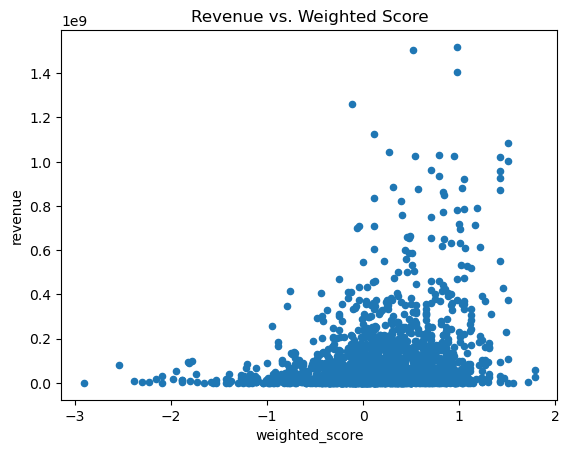

```python
#Before we do that, let's take a quick look at how our factor is doing
filtered_movie_data.plot(y = 'revenue', x = 'weighted_score', kind='scatter')
plt.title("Revenue vs. Weighted Score")
```

Based on this plot, it appears that there is a slightly positive association between weighted scores and revenues, as the lower standardized weighted scores correspond to (on average) lower movie revenues than those with higher scores. But towards the middle of the distribution of scores, the total revenue varies so widely, that it likely won't perform that well in the regression. Regardless, let's just try to use it as a factor just to see.

```python
#extract the list of genre factors to build our regression formula

# genre columns start with a capital letter
genre_cols = filtered_movie_data.filter(regex='^[A-Z]')
print(genre_cols.columns.values)

genres = ' + '.join(genre_cols.columns.values)
genres
```

```
['Action' 'Adventure' 'Animation' 'Biography' 'Comedy' 'Crime'
 'Documentary' 'Drama' 'Family' 'Fantasy' 'History' 'Horror' 'Music'
 'Musical' 'Mystery' 'News' 'Romance' 'Sci_fi' 'Sport' 'Thriller' 'War'
 'Western']
```

```
'Action + Adventure + Animation + Biography + Comedy + Crime + Documentary + Drama + Family + Fantasy + History + Horror + Music + Musical + Mystery + News + Romance + Sci_fi + Sport + Thriller + War + Western'
```

```python
#extract list of language factors for regression
language_cols = filtered_movie_data.filter(regex = '^[a-z][a-z]$')
print(language_cols.columns.values)

#format columns into string to use for our regression formula in statsmodels
languages = " + ".join(language_cols.columns.values)
print(languages)
```

```
['cn' 'da' 'de' 'en' 'es' 'fa' 'fi' 'fr' 'he' 'hi' 'hu' 'id' 'it' 'ja'
 'ko' 'ml' 'mr' 'nb' 'nl' 'no' 'pl' 'pt' 'ro' 'ru' 'sr' 'sv' 'ta' 'te'
 'tr' 'ur' 'vi' 'zh']
cn + da + de + en + es + fa + fi + fr + he + hi + hu + id + it + ja + ko + ml + mr + nb + nl + no + pl + pt + ro + ru + sr + sv + ta + te + tr + ur + vi + zh
```

```python
# split our data by an 80/20 split
train_df, test_df = np.split(filtered_movie_data, [int(.8*len(filtered_movie_data))])
```

```python
# model including one-hot encoded genre and languages
model = sm.ols(formula = 'revenue ~ ' + genres + ' + ' + languages + ' + numVotes + budget + runtime + weighted_score', data = train_df).fit()
model.summary()
```

OLS Regression Results

| Dep. Variable: | revenue | R-squared: | 0.669 |
| --- | --- | --- | --- |
| Model: | OLS | Adj. R-squared: | 0.659 |
| Method: | Least Squares | F-statistic: | 63.26 |
| Date: | Fri, 12 May 2023 | Prob (F-statistic): | 0.00 |
| Time: | 15:29:16 | Log-Likelihood: | -31786. |
| No. Observations: | 1614 | AIC: | 6.367e+04 |
| Df Residuals: | 1563 | BIC: | 6.395e+04 |
| Df Model: | 50 |  |  |
| Covariance Type: | nonrobust |  |  |

|  | coef | std err | t | P>\|t\| | [0.025 | 0.975] |
| --- | --- | --- | --- | --- | --- | --- |
| Intercept | 8.021e+07 | 2.29e+07 | 3.497 | 0.000 | 3.52e+07 | 1.25e+08 |
| Action | -9.099e+06 | 6.46e+06 | -1.409 | 0.159 | -2.18e+07 | 3.56e+06 |
| Adventure | 1.477e+07 | 7.37e+06 | 2.004 | 0.045 | 3.13e+05 | 2.92e+07 |
| Animation | 2.202e+07 | 1.28e+07 | 1.722 | 0.085 | -3.06e+06 | 4.71e+07 |
| Biography | -2.753e+07 | 1.02e+07 | -2.698 | 0.007 | -4.76e+07 | -7.51e+06 |
| Comedy | -4.535e+06 | 6.7e+06 | -0.676 | 0.499 | -1.77e+07 | 8.61e+06 |
| Crime | -1.814e+07 | 6.52e+06 | -2.784 | 0.005 | -3.09e+07 | -5.36e+06 |
| Documentary | 9.543e+06 | 2.45e+07 | 0.390 | 0.697 | -3.85e+07 | 5.76e+07 |
| Drama | -1.551e+07 | 6.49e+06 | -2.391 | 0.017 | -2.82e+07 | -2.79e+06 |
| Family | 7002.0173 | 1.02e+07 | 0.001 | 0.999 | -2e+07 | 2.01e+07 |
| Fantasy | 8.576e+06 | 8.59e+06 | 0.998 | 0.318 | -8.28e+06 | 2.54e+07 |
| History | -1.411e+07 | 1.44e+07 | -0.977 | 0.329 | -4.24e+07 | 1.42e+07 |
| Horror | -8.927e+06 | 8.78e+06 | -1.017 | 0.310 | -2.62e+07 | 8.3e+06 |
| Music | 1.766e+07 | 1.4e+07 | 1.260 | 0.208 | -9.83e+06 | 4.52e+07 |
| Musical | -2.641e+07 | 2.61e+07 | -1.011 | 0.312 | -7.76e+07 | 2.48e+07 |
| Mystery | -5.301e+06 | 8.35e+06 | -0.635 | 0.525 | -2.17e+07 | 1.11e+07 |
| News | 2.551e+07 | 9.14e+07 | 0.279 | 0.780 | -1.54e+08 | 2.05e+08 |
| Romance | 1.95e+06 | 7.09e+06 | 0.275 | 0.783 | -1.2e+07 | 1.59e+07 |
| Sci_fi | -2.473e+07 | 9.05e+06 | -2.733 | 0.006 | -4.25e+07 | -6.98e+06 |
| Sport | -9.955e+06 | 1.31e+07 | -0.762 | 0.446 | -3.56e+07 | 1.57e+07 |
| Thriller | -1.871e+06 | 7.15e+06 | -0.262 | 0.794 | -1.59e+07 | 1.22e+07 |
| War | -2.848e+07 | 1.89e+07 | -1.510 | 0.131 | -6.55e+07 | 8.5e+06 |
| Western | 4.827e+07 | 4.07e+07 | 1.187 | 0.235 | -3.15e+07 | 1.28e+08 |
| cn | 6.016e+06 | 3.68e+07 | 0.164 | 0.870 | -6.61e+07 | 7.81e+07 |
| da | 1.215e-06 | 3.24e-06 | 0.375 | 0.708 | -5.14e-06 | 7.57e-06 |
| de | -1.053e+07 | 3.42e+07 | -0.308 | 0.758 | -7.76e+07 | 5.65e+07 |
| en | -4.156e+06 | 1.19e+07 | -0.348 | 0.728 | -2.76e+07 | 1.93e+07 |
| es | 1.202e+07 | 2.71e+07 | 0.443 | 0.658 | -4.12e+07 | 6.52e+07 |
| fa | 1.453e+07 | 8.67e+07 | 0.168 | 0.867 | -1.56e+08 | 1.85e+08 |
| fi | -2.201e+06 | 8.63e+07 | -0.026 | 0.980 | -1.71e+08 | 1.67e+08 |
| fr | -8.032e+06 | 2.19e+07 | -0.367 | 0.713 | -5.09e+07 | 3.48e+07 |
| he | -6.592e+06 | 8.93e+07 | -0.074 | 0.941 | -1.82e+08 | 1.69e+08 |
| hi | 9.532e+06 | 2.61e+07 | 0.365 | 0.715 | -4.17e+07 | 6.07e+07 |
| hu | -8.222e-07 | 2.07e-06 | -0.397 | 0.691 | -4.88e-06 | 3.24e-06 |
| id | 7.309e-07 | 1.88e-06 | 0.388 | 0.698 | -2.96e-06 | 4.43e-06 |
| it | 1.4e+07 | 3.65e+07 | 0.383 | 0.702 | -5.77e+07 | 8.57e+07 |
| ja | -6.364e+06 | 2.61e+07 | -0.244 | 0.807 | -5.75e+07 | 4.48e+07 |
| ko | -1.003e+07 | 3.97e+07 | -0.253 | 0.801 | -8.79e+07 | 6.79e+07 |
| ml | -1.964e-07 | 5.16e-07 | -0.381 | 0.703 | -1.21e-06 | 8.16e-07 |
| mr | -8.122e-08 | 2.17e-07 | -0.374 | 0.708 | -5.07e-07 | 3.45e-07 |
| nb | -3.107e-07 | 7.87e-07 | -0.395 | 0.693 | -1.85e-06 | 1.23e-06 |
| nl | 2.292e+07 | 5.07e+07 | 0.452 | 0.651 | -7.65e+07 | 1.22e+08 |
| no | -1.575e+07 | 8.58e+07 | -0.184 | 0.854 | -1.84e+08 | 1.52e+08 |
| pl | 5.128e+07 | 8.77e+07 | 0.585 | 0.559 | -1.21e+08 | 2.23e+08 |
| pt | -2.311e+07 | 5.04e+07 | -0.459 | 0.646 | -1.22e+08 | 7.57e+07 |
| ro | 1.202e+07 | 6.1e+07 | 0.197 | 0.844 | -1.08e+08 | 1.32e+08 |
| ru | 6.752e+06 | 2.37e+07 | 0.285 | 0.775 | -3.97e+07 | 5.32e+07 |
| sr | 3.525e+07 | 8.54e+07 | 0.413 | 0.680 | -1.32e+08 | 2.03e+08 |
| sv | -1.702e+07 | 6.1e+07 | -0.279 | 0.780 | -1.37e+08 | 1.03e+08 |
| ta | 1.236e+07 | 3.33e+07 | 0.372 | 0.710 | -5.29e+07 | 7.76e+07 |
| te | 1.008e+07 | 6.13e+07 | 0.165 | 0.869 | -1.1e+08 | 1.3e+08 |
| tr | -1.888e+07 | 8.58e+07 | -0.220 | 0.826 | -1.87e+08 | 1.49e+08 |
| ur | 0 | 0 | nan | nan | 0 | 0 |
| vi | -6e+05 | 8.55e+07 | -0.007 | 0.994 | -1.68e+08 | 1.67e+08 |
| zh | -3.294e+06 | 3.08e+07 | -0.107 | 0.915 | -6.37e+07 | 5.71e+07 |
| numVotes | 6.011e+07 | 2.59e+06 | 23.238 | 0.000 | 5.5e+07 | 6.52e+07 |
| budget | 8.282e+07 | 2.98e+06 | 27.777 | 0.000 | 7.7e+07 | 8.87e+07 |
| runtime | 2.757e+05 | 1.61e+05 | 1.717 | 0.086 | -3.93e+04 | 5.91e+05 |
| weighted_score | -1.033e+07 | 4.83e+06 | -2.137 | 0.033 | -1.98e+07 | -8.47e+05 |

| Omnibus: | 689.249 | Durbin-Watson: | 1.957 |
| --- | --- | --- | --- |
| Prob(Omnibus): | 0.000 | Jarque-Bera (JB): | 19968.915 |
| Skew: | 1.386 | Prob(JB): | 0.00 |
| Kurtosis: | 20.008 | Cond. No. | 2.77e+16 |

Notes:  
[1] Standard Errors assume that the covariance matrix of the errors is correctly specified.  
[2] The smallest eigenvalue is 2.59e-26. This might indicate that there are  
strong multicollinearity problems or that the design matrix is singular.

```python
# mean squared error on train and test dataset
print('The training mean squared error is {}'.format(mse(train_df['revenue'], model.predict(train_df))))
print('The testing mean squared error is {}'.format(mse(test_df['revenue'], model.predict(test_df))))
```

```
The training mean squared error is 7469060398945404.0
The testing mean squared error is 1.214531236819125e+16
```

Overall, this regression seems to be performing reasonably well, with an r^2 value of 0.669 which corresponds to the proportion of variance explained by our model. But given the sparsity of the genre features, this model may introduce some level of overfitting to the model. Let's see how well the model performs without the encoded genre and language variables.

```python
model_no_encoding = sm.ols(formula = 'revenue ~ numVotes + budget + runtime + weighted_score', data = train_df).fit()
model_no_encoding.summary()
```

OLS Regression Results

| Dep. Variable: | revenue | R-squared: | 0.653 |
| --- | --- | --- | --- |
| Model: | OLS | Adj. R-squared: | 0.652 |
| Method: | Least Squares | F-statistic: | 757.2 |
| Date: | Fri, 12 May 2023 | Prob (F-statistic): | 0.00 |
| Time: | 15:36:44 | Log-Likelihood: | -31824. |
| No. Observations: | 1614 | AIC: | 6.366e+04 |
| Df Residuals: | 1609 | BIC: | 6.369e+04 |
| Df Model: | 4 |  |  |
| Covariance Type: | nonrobust |  |  |

|  | coef | std err | t | P>\|t\| | [0.025 | 0.975] |
| --- | --- | --- | --- | --- | --- | --- |
| Intercept | 8.737e+07 | 1.36e+07 | 6.442 | 0.000 | 6.08e+07 | 1.14e+08 |
| numVotes | 5.934e+07 | 2.51e+06 | 23.642 | 0.000 | 5.44e+07 | 6.43e+07 |
| budget | 8.739e+07 | 2.56e+06 | 34.104 | 0.000 | 8.24e+07 | 9.24e+07 |
| runtime | 2.189e+04 | 1.25e+05 | 0.175 | 0.861 | -2.23e+05 | 2.67e+05 |
| weighted_score | -1.131e+07 | 4.52e+06 | -2.499 | 0.013 | -2.02e+07 | -2.43e+06 |

| Omnibus: | 723.555 | Durbin-Watson: | 1.951 |
| --- | --- | --- | --- |
| Prob(Omnibus): | 0.000 | Jarque-Bera (JB): | 18058.879 |
| Skew: | 1.534 | Prob(JB): | 0.00 |
| Kurtosis: | 19.097 | Cond. No. | 687. |

Notes:  
[1] Standard Errors assume that the covariance matrix of the errors is correctly specified.

```python
# mean squared error on test and train dataset
print('The training mean squared error is {}'.format(mse(train_df['revenue'], model_no_encoding.predict(train_df))))
print('The training mean squared error is {}'.format(mse(test_df['revenue'], model_no_encoding.predict(test_df))))
```

```
The training mean squared error is 7834965392209237.0
The training mean squared error is 1.2392810036864994e+16
```

Interestingly, the R^2 value between the original model and this model do not vary by much. Our mean squared error did increase but is of the same order of magnitude. This means that our genre and language factors have limited prediction power on their own.

### Penalized Regression (Ridge & LASSO)

Given the large number of factors that we have present in this dataset, it may be fruitful to pursue a penalized regression. Penalized regression helps in the case that we have a lot of factors, and we aren't as confident that each one is actually helping our predictive model out of sample. The idea behind penalized regression is that there is a "cost" to pay for decreasing variance in the in-sample prediction. This cost is controlled by a parameter called lamdba, or alpha in the scikit-learn library, which indicates how much of a decrease in variance is needed to justify the increase in bias. In using this kind of regression, we hope that there is some implicit feature selection in that low beta regressors will become either closer to 0 or exactly 0.

For this we will compare two different methods of penalized regression: Lasso Regression and Ridge Regression and we will interpret results at the end of the experiment. In addition, we will use a technique called cross validation which will be explained below to tune the alpha hyperparameter for what we hope will produce the best out of sample performance.

```python
#LASSO

train_index_cutoff = int(0.8 * len(filtered_movie_data.index))

regression_cols = np.concatenate((language_cols.columns.values, genre_cols.columns.values,['numVotes', 'runtime', 'budget', 'weighted_score']))
x_data_train = filtered_movie_data[regression_cols].iloc[:train_index_cutoff]
x_data_test = filtered_movie_data[regression_cols].iloc[train_index_cutoff:]

x_data_train.fillna(x_data_train.mean(), inplace=True)
x_data_test.fillna(x_data_test.mean(), inplace=True)

y_data_train = filtered_movie_data['revenue'].iloc[:train_index_cutoff]
y_data_test = filtered_movie_data['revenue'].iloc[train_index_cutoff:]

clf = LassoCV(n_alphas=100, cv = 10, random_state = 0).fit(x_data_train, y_data_train)
print(f'The intercept is {clf.intercept_}')
print(f'The parameters are {clf.coef_}')
print(f'The training mean squared error is {mean_squared_error(clf.predict(x_data_train), y_data_train)}')
```

```
The intercept is 78023159.5949896
The parameters are [        0.                 0.                -0.
        -0.                 0.                 0.
         0.                -0.                 0.
         0.                 0.                 0.
         0.                 0.                -0.
         0.                 0.                 0.
         0.                -0.                 0.
        -0.                 0.                 0.
         0.                -0.                 0.
         0.                -0.                 0.
         0.                -0.          -2243451.51705225
  17251864.09681797   5968474.76389323 -13226267.67145596
         0.         -12944740.49113632         0.
 -10142771.11080888         0.           2812966.09853589
        -0.                -0.                 0.
        -0.                -0.                 0.
    500387.42165468 -13677973.05305113        -0.
        -0.                -0.                 0.
  58218903.80785678    154476.91291796  82475627.7678484
  -5040788.53201563]
The training mean squared error is 7581692297231519.0
```

As we can see with cross validated lasso regression, most of the regressors are zeroed out. This is because the goal of the lasso regression is to wrangle together the useful predictors with a harsh penalty associated with any decrease in variance. As we can see with the model the mean squared error, is higher than that of the ridge regression and the OLS, but the key trade-off is a huge increase in the explainability of the model. Now there are only a few factors that are used to determine the box office revenue predictions.

```python
#let's look at our testing errors to see if this model generalizes well
print(f'The testing mean squared error is {mean_squared_error(clf.predict(x_data_test), y_data_test)}')
```

```
The testing mean squared error is 1.2202909511871776e+16
```

```python
clf = RidgeCV(cv = 10).fit(x_data_train, y_data_train)
print(f'The intercept is {clf.intercept_}')
print(f'The parameters are {clf.coef_}')
print(f'The training mean squared error is {mean_squared_error(clf.predict(x_data_train), y_data_train)}')
```

```
The intercept is 76635130.21975997
The parameters are [ 1.37347120e+06  0.00000000e+00 -4.62511346e+06 -4.55440975e+06
  5.58537816e+06  9.78637685e+05 -4.22211199e+05 -6.29124351e+06
 -3.21810890e+05  3.50589758e+06  0.00000000e+00  0.00000000e+00
  4.82404525e+06 -2.50117890e+06 -4.44104203e+06  0.00000000e+00
  0.00000000e+00  0.00000000e+00  4.15461742e+06 -1.52674151e+06
  3.54067509e+06 -5.09734673e+06  1.97200999e+06  2.89809118e+06
  3.03028085e+06 -2.80012549e+06  3.93997011e+06  1.52603612e+06
 -1.50979099e+06  0.00000000e+00  3.66523954e+04 -3.27474856e+06
 -7.59312530e+06  1.61363132e+07  1.97847223e+07 -2.44353085e+07
 -3.07043637e+06 -1.65150492e+07  7.03408871e+06 -1.47589805e+07
  1.76141465e+06  8.87984407e+06 -1.12550087e+07 -7.53672590e+06
  1.48395917e+07 -1.29468899e+07 -4.06719045e+06  2.44458928e+06
  3.00261364e+06 -2.16879214e+07 -7.54318150e+06 -1.08520701e+06
 -1.81572835e+07  1.58732123e+07  5.97100923e+07  2.81812848e+05
  8.19263176e+07 -9.39474455e+06]
The training mean squared error is 7482502554219059.0
```

```python
#let's again look at our test dataset
print(f'The testing mean squared error is {mean_squared_error(clf.predict(x_data_test), y_data_test)}')
```

```
The testing mean squared error is 1.2149915061007224e+16
```

### Random Forest Regression

```python
param_grid = {
    'n_estimators': np.arange(25, 150, 5),
    'max_features': ['sqrt', 'log2', None],
    'max_depth': np.arange(3,18,3),
    'max_leaf_nodes': np.arange(3, 18, 3),
}

#randomized grid search helps with model performance speed because it randomly samples model parameters that lie within our parameter grid
reg_model = model_selection.RandomizedSearchCV(RandomForestRegressor(), param_distributions= param_grid, random_state=0, n_iter = 10, cv = 10)
reg_model.fit(x_data_train, y_data_train)
print(reg_model.best_estimator_)
```

```
RandomForestRegressor(max_depth=6, max_features=None, max_leaf_nodes=9,
                      n_estimators=70)
```

```python
print(f"The training mean squared error for the best random forest estimator is {mean_squared_error(reg_model.best_estimator_.predict(x_data_train), y_data_train)}")
```

```
The training mean squared error for the best random forest estimator is 4910267696517688.0
```

```python
print(f"The testing mean squared error for the best random forest estimator is {mean_squared_error(reg_model.best_estimator_.predict(x_data_test), y_data_test)}")
```

```
The testing mean squared error for the best random forest estimator is 1.3012441718504568e+16
```

```python
regression_cols = ['numVotes', 'runtime', 'budget', 'weighted_score']
x_data_train = filtered_movie_data[regression_cols].iloc[:train_index_cutoff]
x_data_test = filtered_movie_data[regression_cols].iloc[train_index_cutoff:]

param_grid = {
    'n_estimators': np.arange(25, 150, 5),
    'max_features': ['sqrt', 'log2', None],
    'max_depth': np.arange(3,18,3),
    'max_leaf_nodes': np.arange(3, 18, 3),
}

#randomized grid search helps with model performance speed because it randomly samples model parameters that lie within our parameter grid
reg_model = model_selection.RandomizedSearchCV(RandomForestRegressor(), param_distributions= param_grid, random_state=0, n_iter = 10, cv = 10)
reg_model.fit(x_data_train, y_data_train)
print(reg_model.best_estimator_)
```

```
RandomForestRegressor(max_depth=6, max_features=None, max_leaf_nodes=9,
                      n_estimators=70)
```

```python
print(f"The training mean squared error for the best random forest estimator is {mean_squared_error(reg_model.best_estimator_.predict(x_data_train), y_data_train)}")
```

```
The training mean squared error for the best random forest estimator is 5200867036213345.0
```

```python
print(f"The testing mean squared error for the best random forest estimator is {mean_squared_error(reg_model.best_estimator_.predict(x_data_test), y_data_test)}")
```

```
The testing mean squared error for the best random forest estimator is 1.2864843736480812e+16
```

## Conclusion

Future analysis of blockbuster films would explore more of the graph data that we produced through more social network analysis techniques. Our current analysis highlighted some of the well-established directors and actors in the industry based on the number of movies that they were involved in. After all, actors tend to become popular if they star in well-received movies, the ones that tend to rake in the most revenue. Different networks and combinations of actors and directors may very well perform differently from one another and could be an important factor in predicting the revenue that a movie would produce.